# Исследование эффективности рекламных кампаний

**Цель исследования** - Оценка прибыльности рекламных кампаний. На основании информации о пользователях, покупках, а также о стоимости привлечения клиентов определяется эффективность проводимых рекламных кампаний, а также планируются шаги по повышению их прибыльности.

**Ход исследования**

Данные получены из файлов с расширением .csv. К данным приложена документация, однако могут встречаться пропуски или значения, искажающие данные. Поэтому перед проверкой гипотез требуется провести обзор данных и их обработку.

Далее необходимо провести анализ следующих параметров:

- каналы привлечения пользователей
- перечень используемых устройств
- стоимость привлечения пользователей из различных рекламных каналов
- сколько денег в среднем приносит клиент
- окупаемость расходов на привлечение, а также срок окупаемости
- факторы, затрудняющие привлечение клиентов

```python
import pandas as pd
import numpy as np
from datetime import datetime, timedelta
from matplotlib import pyplot as plt
```

```python
try:
    visits = pd.read_csv('Datasets/visits_info_short.csv')
except:
    visits = pd.read_csv('https://code.s3.yandex.net/datasets/ch04_final_visits.csv')

try:
    orders = pd.read_csv('Datasets/orders_info_short.csv')
except:
    orders = pd.read_csv('https://code.s3.yandex.net/datasets/ch04_final_orders.csv')

try:
    costs = pd.read_csv('Datasets/costs_info_short.csv')
except:
    costs = pd.read_csv('https://code.s3.yandex.net/datasets/ch04_final_costs.csv')
```

## Обзор данных

Таблица `visits` содержит информацию о посещениях (пользовательских сессиях)

```python
visits.head()
```

|  | User Id | Region | Device | Channel | Session Start | Session End |
| --- | --- | --- | --- | --- | --- | --- |
| 0 | 981449118918 | United States | iPhone | organic | 2019-05-01 02:36:01 | 2019-05-01 02:45:01 |
| 1 | 278965908054 | United States | iPhone | organic | 2019-05-01 04:46:31 | 2019-05-01 04:47:35 |
| 2 | 590706206550 | United States | Mac | organic | 2019-05-01 14:09:25 | 2019-05-01 15:32:08 |
| 3 | 326433527971 | United States | Android | TipTop | 2019-05-01 00:29:59 | 2019-05-01 00:54:25 |
| 4 | 349773784594 | United States | Mac | organic | 2019-05-01 03:33:35 | 2019-05-01 03:57:40 |

`User Id` — уникальный идентификатор пользователя,  
`Region` — страна пользователя,  
`Device` — тип устройства пользователя,  
`Channel` — идентификатор источника перехода,  
`Session Start` — дата и время начала сессии,  
`Session End` — дата и время окончания сессии.

Таблица `orders` содержит информацию о заказах

```python
orders.head()
```

|  | User Id | Event Dt | Revenue |
| --- | --- | --- | --- |
| 0 | 188246423999 | 2019-05-01 23:09:52 | 4.99 |
| 1 | 174361394180 | 2019-05-01 12:24:04 | 4.99 |
| 2 | 529610067795 | 2019-05-01 11:34:04 | 4.99 |
| 3 | 319939546352 | 2019-05-01 15:34:40 | 4.99 |
| 4 | 366000285810 | 2019-05-01 13:59:51 | 4.99 |

`User Id` — уникальный идентификатор пользователя,  
`Event Dt` — дата и время покупки,  
`Revenue` — сумма заказа.

Таблица `costs` содержит информацию о стоимости привлечения клиентов

```python
costs.head()
```

|  | dt | Channel | costs |
| --- | --- | --- | --- |
| 0 | 2019-05-01 | FaceBoom | 113.3 |
| 1 | 2019-05-02 | FaceBoom | 78.1 |
| 2 | 2019-05-03 | FaceBoom | 85.8 |
| 3 | 2019-05-04 | FaceBoom | 136.4 |
| 4 | 2019-05-05 | FaceBoom | 122.1 |

`dt` — дата проведения рекламной кампании,  
`Channel` — идентификатор рекламного источника,  
`costs` — расходы на эту кампанию.

## Предобработка данных

Для всех таблиц необходимо сделать следующее:

```python
visits = visits.rename(columns={
    'User Id':'user_id',
    'Region':'region',
    'Device':'device',
    'Channel':'channel',
    'Session Start':'session_start',
    'Session End':'session_end'
})
```

```python
visits['session_start'] = pd.to_datetime(visits['session_start'])
visits['session_end'] = pd.to_datetime(visits['session_end'])
```

```python
visits.info()
```

```
<class 'pandas.core.frame.DataFrame'>
RangeIndex: 309901 entries, 0 to 309900
Data columns (total 6 columns):
 #   Column         Non-Null Count   Dtype
---  ------         --------------   -----
 0   user_id        309901 non-null  int64
 1   region         309901 non-null  object
 2   device         309901 non-null  object
 3   channel        309901 non-null  object
 4   session_start  309901 non-null  datetime64[ns]
 5   session_end    309901 non-null  datetime64[ns]
dtypes: datetime64[ns](2), int64(1), object(3)
memory usage: 14.2+ MB
```

```python
visits['region'].unique()
```

```
array(['United States', 'UK', 'France', 'Germany'], dtype=object)
```

```python
visits['device'].unique()
```

```
array(['iPhone', 'Mac', 'Android', 'PC'], dtype=object)
```

```python
visits['region'].unique()
```

```
array(['United States', 'UK', 'France', 'Germany'], dtype=object)
```

```python
orders = orders.rename(columns={
    'User Id':'user_id',
    'Event Dt':'event_dt',
    'Revenue':'revenue'
})
```

```python
orders['event_dt'] = pd.to_datetime(orders['event_dt'])
```

```python
orders.info()
```

```
<class 'pandas.core.frame.DataFrame'>
RangeIndex: 40212 entries, 0 to 40211
Data columns (total 3 columns):
 #   Column    Non-Null Count  Dtype
---  ------    --------------  -----
 0   user_id   40212 non-null  int64
 1   event_dt  40212 non-null  datetime64[ns]
 2   revenue   40212 non-null  float64
dtypes: datetime64[ns](1), float64(1), int64(1)
memory usage: 942.6 KB
```

```python
costs = costs.rename(columns={'Channel':'channel'})
```

```python
costs['dt'] = pd.to_datetime(costs['dt']).dt.date
```

```python
costs['channel'].unique()
```

```
array(['FaceBoom', 'MediaTornado', 'RocketSuperAds', 'TipTop', 'YRabbit',
       'AdNonSense', 'LeapBob', 'OppleCreativeMedia', 'WahooNetBanner',
       'lambdaMediaAds'], dtype=object)
```

```python
costs.info()
```

```
<class 'pandas.core.frame.DataFrame'>
RangeIndex: 1800 entries, 0 to 1799
Data columns (total 3 columns):
 #   Column   Non-Null Count  Dtype
---  ------   --------------  -----
 0   dt       1800 non-null   object
 1   channel  1800 non-null   object
 2   costs    1800 non-null   float64
dtypes: float64(1), object(2)
memory usage: 42.3+ KB
```

Следовательно, можно приступать к проверке гипотез.

## Задание функций для расчета и визуализации

С целью автоматизации исследования задаются следующие функции для расчета основных параметров:

- `get_profiles` — для создания профилей пользователей,
- `get_retention` — для подсчёта Retention Rate (коэффициент удержания пользователей),
- `get_conversion` — для подсчёта конверсии,
- `get_ltv` — для подсчёта LTV (lifetime value - выручка, полученная от клиента за все время).

А также ряд функция для визуализации:

- `filter_data` — для сглаживания данных,
- `plot_retention` — для построения графика Retention Rate,
- `plot_conversion` — для построения графика конверсии,
- `plot_ltv_roi` — для визуализации LTV и ROI (return of investment - окупаемость вложенных затрат).

```python
# функция для создания пользовательских профилей

def get_profiles(sessions, orders, ad_costs, event_names=[]):

    # находим параметры первых посещений
    profiles = (
        sessions.sort_values(by=['user_id', 'session_start'])
        .groupby('user_id')
        .agg(
            {
                'session_start': 'first',
                'channel': 'first',
                'device': 'first',
                'region': 'first',
            }
        )
        .rename(columns={'session_start': 'first_ts'})
        .reset_index()
    )

    # для когортного анализа определяем дату первого посещения
    # и первый день месяца, в который это посещение произошло
    profiles['dt'] = profiles['first_ts'].dt.date
    profiles['month'] = profiles['first_ts'].astype('datetime64[M]')

    # добавляем признак платящих пользователей
    profiles['payer'] = profiles['user_id'].isin(orders['user_id'].unique())

    # считаем количество уникальных пользователей
    # с одинаковыми источником и датой привлечения
    new_users = (
        profiles.groupby(['dt', 'channel'])
        .agg({'user_id': 'nunique'})
        .rename(columns={'user_id': 'unique_users'})
        .reset_index()
    )

    # объединяем траты на рекламу и число привлечённых пользователей
    ad_costs = ad_costs.merge(new_users, on=['dt', 'channel'], how='left')

    # делим рекламные расходы на число привлечённых пользователей
    ad_costs['acquisition_cost'] = ad_costs['costs'] / ad_costs['unique_users']

    # добавляем стоимость привлечения в профили
    profiles = profiles.merge(
        ad_costs[['dt', 'channel', 'acquisition_cost']],
        on=['dt', 'channel'],
        how='left',
    )

    # стоимость привлечения органических пользователей равна нулю
    profiles['acquisition_cost'] = profiles['acquisition_cost'].fillna(0)

    return profiles
```

```python
# функция для расчёта удержания

def get_retention(
    profiles,
    sessions,
    observation_date,
    horizon_days,
    dimensions=[],
    ignore_horizon=False,
):

    # добавляем столбец payer в передаваемый dimensions список
    dimensions = ['payer'] + dimensions

    # исключаем пользователей, не «доживших» до горизонта анализа
    last_suitable_acquisition_date = observation_date
    if not ignore_horizon:
        last_suitable_acquisition_date = observation_date - timedelta(
            days=horizon_days - 1
        )
    result_raw = profiles.query('dt <= @last_suitable_acquisition_date')

    # собираем «сырые» данные для расчёта удержания
    result_raw = result_raw.merge(
        sessions[['user_id', 'session_start']], on='user_id', how='left'
    )
    result_raw['lifetime'] = (
        result_raw['session_start'] - result_raw['first_ts']
    ).dt.days

    # функция для группировки таблицы по желаемым признакам
    def group_by_dimensions(df, dims, horizon_days):
        result = df.pivot_table(
            index=dims, columns='lifetime', values='user_id', aggfunc='nunique'
        )
        cohort_sizes = (
            df.groupby(dims)
            .agg({'user_id': 'nunique'})
            .rename(columns={'user_id': 'cohort_size'})
        )
        result = cohort_sizes.merge(result, on=dims, how='left').fillna(0)
        result = result.div(result['cohort_size'], axis=0)
        result = result[['cohort_size'] + list(range(horizon_days))]
        result['cohort_size'] = cohort_sizes
        return result

    # получаем таблицу удержания
    result_grouped = group_by_dimensions(result_raw, dimensions, horizon_days)

    # получаем таблицу динамики удержания
    result_in_time = group_by_dimensions(
        result_raw, dimensions + ['dt'], horizon_days
    )

    # возвращаем обе таблицы и сырые данные
    return result_raw, result_grouped, result_in_time
```

```python
# функция для расчёта конверсии

def get_conversion(
    profiles,
    purchases,
    observation_date,
    horizon_days,
    dimensions=[],
    ignore_horizon=False,
):

    # исключаем пользователей, не «доживших» до горизонта анализа
    last_suitable_acquisition_date = observation_date
    if not ignore_horizon:
        last_suitable_acquisition_date = observation_date - timedelta(
            days=horizon_days - 1
        )
    result_raw = profiles.query('dt <= @last_suitable_acquisition_date')

    # определяем дату и время первой покупки для каждого пользователя
    first_purchases = (
        purchases.sort_values(by=['user_id', 'event_dt'])
        .groupby('user_id')
        .agg({'event_dt': 'first'})
        .reset_index()
    )

    # добавляем данные о покупках в профили
    result_raw = result_raw.merge(
        first_purchases[['user_id', 'event_dt']], on='user_id', how='left'
    )

    # рассчитываем лайфтайм для каждой покупки
    result_raw['lifetime'] = (
        result_raw['event_dt'] - result_raw['first_ts']
    ).dt.days

    # группируем по cohort, если в dimensions ничего нет
    if len(dimensions) == 0:
        result_raw['cohort'] = 'All users'
        dimensions = dimensions + ['cohort']

    # функция для группировки таблицы по желаемым признакам
    def group_by_dimensions(df, dims, horizon_days):
        result = df.pivot_table(
            index=dims, columns='lifetime', values='user_id', aggfunc='nunique'
        )
        result = result.fillna(0).cumsum(axis = 1)
        cohort_sizes = (
            df.groupby(dims)
            .agg({'user_id': 'nunique'})
            .rename(columns={'user_id': 'cohort_size'})
        )
        result = cohort_sizes.merge(result, on=dims, how='left').fillna(0)
        # делим каждую «ячейку» в строке на размер когорты
        # и получаем conversion rate
        result = result.div(result['cohort_size'], axis=0)
        result = result[['cohort_size'] + list(range(horizon_days))]
        result['cohort_size'] = cohort_sizes
        return result

    # получаем таблицу конверсии
    result_grouped = group_by_dimensions(result_raw, dimensions, horizon_days)

    # для таблицы динамики конверсии убираем 'cohort' из dimensions
    if 'cohort' in dimensions:
        dimensions = []

    # получаем таблицу динамики конверсии
    result_in_time = group_by_dimensions(
        result_raw, dimensions + ['dt'], horizon_days
    )

    # возвращаем обе таблицы и сырые данные
    return result_raw, result_grouped, result_in_time
```

```python
# функция для расчёта LTV и ROI

def get_ltv(
    profiles,
    purchases,
    observation_date,
    horizon_days,
    dimensions=[],
    ignore_horizon=False,
):

    # исключаем пользователей, не «доживших» до горизонта анализа
    last_suitable_acquisition_date = observation_date
    if not ignore_horizon:
        last_suitable_acquisition_date = observation_date - timedelta(
            days=horizon_days - 1
        )
    result_raw = profiles.query('dt <= @last_suitable_acquisition_date')
    # добавляем данные о покупках в профили
    result_raw = result_raw.merge(
        purchases[['user_id', 'event_dt', 'revenue']], on='user_id', how='left'
    )
    # рассчитываем лайфтайм пользователя для каждой покупки
    result_raw['lifetime'] = (
        result_raw['event_dt'] - result_raw['first_ts']
    ).dt.days
    # группируем по cohort, если в dimensions ничего нет
    if len(dimensions) == 0:
        result_raw['cohort'] = 'All users'
        dimensions = dimensions + ['cohort']

    # функция группировки по желаемым признакам
    def group_by_dimensions(df, dims, horizon_days):
        # строим «треугольную» таблицу выручки
        result = df.pivot_table(
            index=dims, columns='lifetime', values='revenue', aggfunc='sum'
        )
        # находим сумму выручки с накоплением
        result = result.fillna(0).cumsum(axis=1)
        # вычисляем размеры когорт
        cohort_sizes = (
            df.groupby(dims)
            .agg({'user_id': 'nunique'})
            .rename(columns={'user_id': 'cohort_size'})
        )
        # объединяем размеры когорт и таблицу выручки
        result = cohort_sizes.merge(result, on=dims, how='left').fillna(0)
        # считаем LTV: делим каждую «ячейку» в строке на размер когорты
        result = result.div(result['cohort_size'], axis=0)
        # исключаем все лайфтаймы, превышающие горизонт анализа
        result = result[['cohort_size'] + list(range(horizon_days))]
        # восстанавливаем размеры когорт
        result['cohort_size'] = cohort_sizes

        # собираем датафрейм с данными пользователей и значениями CAC,
        # добавляя параметры из dimensions
        cac = df[['user_id', 'acquisition_cost'] + dims].drop_duplicates()

        # считаем средний CAC по параметрам из dimensions
        cac = (
            cac.groupby(dims)
            .agg({'acquisition_cost': 'mean'})
            .rename(columns={'acquisition_cost': 'cac'})
        )

        # считаем ROI: делим LTV на CAC
        roi = result.div(cac['cac'], axis=0)

        # удаляем строки с бесконечным ROI
        roi = roi[~roi['cohort_size'].isin([np.inf])]

        # восстанавливаем размеры когорт в таблице ROI
        roi['cohort_size'] = cohort_sizes

        # добавляем CAC в таблицу ROI
        roi['cac'] = cac['cac']

        # в финальной таблице оставляем размеры когорт, CAC
        # и ROI в лайфтаймы, не превышающие горизонт анализа
        roi = roi[['cohort_size', 'cac'] + list(range(horizon_days))]

        # возвращаем таблицы LTV и ROI
        return result, roi

    # получаем таблицы LTV и ROI
    result_grouped, roi_grouped = group_by_dimensions(
        result_raw, dimensions, horizon_days
    )

    # для таблиц динамики убираем 'cohort' из dimensions
    if 'cohort' in dimensions:
        dimensions = []

    # получаем таблицы динамики LTV и ROI
    result_in_time, roi_in_time = group_by_dimensions(
        result_raw, dimensions + ['dt'], horizon_days
    )

    return (
        result_raw,  # сырые данные
        result_grouped,  # таблица LTV
        result_in_time,  # таблица динамики LTV
        roi_grouped,  # таблица ROI
        roi_in_time,  # таблица динамики ROI
    )
```

```python
# функция для сглаживания фрейма

def filter_data(df, window):
    # для каждого столбца применяем скользящее среднее
    for column in df.columns.values:
        df[column] = df[column].rolling(window).mean()
    return df
```

```python
# функция для визуализации удержания

def plot_retention(retention, retention_history, horizon, window=7):

    # задаём размер сетки для графиков
    plt.figure(figsize=(15, 10))

    # исключаем размеры когорт и удержание первого дня
    retention = retention.drop(columns=['cohort_size', 0])
    # в таблице динамики оставляем только нужный лайфтайм
    retention_history = retention_history.drop(columns=['cohort_size'])[
        [horizon - 1]
    ]

    # если в индексах таблицы удержания только payer,
    # добавляем второй признак — cohort
    if retention.index.nlevels == 1:
        retention['cohort'] = 'All users'
        retention = retention.reset_index().set_index(['cohort', 'payer'])

    # в таблице графиков — два столбца и две строки, четыре ячейки
    # в первой строим кривые удержания платящих пользователей
    ax1 = plt.subplot(2, 2, 1)
    retention.query('payer == True').droplevel('payer').T.plot(
        grid=True, ax=ax1
    )
    plt.legend()
    plt.xlabel('Лайфтайм')
    plt.title('Удержание платящих пользователей')

    # во второй ячейке строим кривые удержания неплатящих
    # вертикальная ось — от графика из первой ячейки
    ax2 = plt.subplot(2, 2, 2, sharey=ax1)
    retention.query('payer == False').droplevel('payer').T.plot(
        grid=True, ax=ax2
    )
    plt.legend()
    plt.xlabel('Лайфтайм')
    plt.title('Удержание неплатящих пользователей')

    # в третьей ячейке — динамика удержания платящих
    ax3 = plt.subplot(2, 2, 3)
    # получаем названия столбцов для сводной таблицы
    columns = [
        name
        for name in retention_history.index.names
        if name not in ['dt', 'payer']
    ]
    # фильтруем данные и строим график
    filtered_data = retention_history.query('payer == True').pivot_table(
        index='dt', columns=columns, values=horizon - 1, aggfunc='mean'
    )
    filter_data(filtered_data, window).plot(grid=True, ax=ax3)
    plt.xlabel('Дата привлечения')
    plt.title(
        'Динамика удержания платящих пользователей на {}-й день'.format(
            horizon
        )
    )

    # в чётвертой ячейке — динамика удержания неплатящих
    ax4 = plt.subplot(2, 2, 4, sharey=ax3)
    # фильтруем данные и строим график
    filtered_data = retention_history.query('payer == False').pivot_table(
        index='dt', columns=columns, values=horizon - 1, aggfunc='mean'
    )
    filter_data(filtered_data, window).plot(grid=True, ax=ax4)
    plt.xlabel('Дата привлечения')
    plt.title(
        'Динамика удержания неплатящих пользователей на {}-й день'.format(
            horizon
        )
    )

    plt.tight_layout()
    plt.show()
```

```python
# функция для визуализации конверсии

def plot_conversion(conversion, conversion_history, horizon, window=7):

    # задаём размер сетки для графиков
    plt.figure(figsize=(15, 5))

    # исключаем размеры когорт
    conversion = conversion.drop(columns=['cohort_size'])
    # в таблице динамики оставляем только нужный лайфтайм
    conversion_history = conversion_history.drop(columns=['cohort_size'])[
        [horizon - 1]
    ]

    # первый график — кривые конверсии
    ax1 = plt.subplot(1, 2, 1)
    conversion.T.plot(grid=True, ax=ax1)
    plt.legend()
    plt.xlabel('Лайфтайм')
    plt.title('Конверсия пользователей')

    # второй график — динамика конверсии
    ax2 = plt.subplot(1, 2, 2, sharey=ax1)
    columns = [
        # столбцами сводной таблицы станут все столбцы индекса, кроме даты
        name for name in conversion_history.index.names if name not in ['dt']
    ]
    filtered_data = conversion_history.pivot_table(
        index='dt', columns=columns, values=horizon - 1, aggfunc='mean'
    )
    filter_data(filtered_data, window).plot(grid=True, ax=ax2)
    plt.xlabel('Дата привлечения')
    plt.title('Динамика конверсии пользователей на {}-й день'.format(horizon))

    plt.tight_layout()
    plt.show()
```

```python
# функция для визуализации LTV и ROI

def plot_ltv_roi(ltv, ltv_history, roi, roi_history, horizon, window=7):

    # задаём сетку отрисовки графиков
    plt.figure(figsize=(20, 10))

    # из таблицы ltv исключаем размеры когорт
    ltv = ltv.drop(columns=['cohort_size'])
    # в таблице динамики ltv оставляем только нужный лайфтайм
    ltv_history = ltv_history.drop(columns=['cohort_size'])[[horizon - 1]]

    # стоимость привлечения запишем в отдельный фрейм
    cac_history = roi_history[['cac']]

    # из таблицы roi исключаем размеры когорт и cac
    roi = roi.drop(columns=['cohort_size', 'cac'])
    # в таблице динамики roi оставляем только нужный лайфтайм
    roi_history = roi_history.drop(columns=['cohort_size', 'cac'])[
        [horizon - 1]
    ]

    # первый график — кривые ltv
    ax1 = plt.subplot(2, 3, 1)
    ltv.T.plot(grid=True, ax=ax1)
    plt.legend()
    plt.xlabel('Лайфтайм')
    plt.title('LTV')

    # второй график — динамика ltv
    ax2 = plt.subplot(2, 3, 2, sharey=ax1)
    # столбцами сводной таблицы станут все столбцы индекса, кроме даты
    columns = [name for name in ltv_history.index.names if name not in ['dt']]
    filtered_data = ltv_history.pivot_table(
        index='dt', columns=columns, values=horizon - 1, aggfunc='mean'
    )
    filter_data(filtered_data, window).plot(grid=True, ax=ax2)
    plt.xlabel('Дата привлечения')
    plt.title('Динамика LTV пользователей на {}-й день'.format(horizon))

    # третий график — динамика cac
    ax3 = plt.subplot(2, 3, 3, sharey=ax1)
    # столбцами сводной таблицы станут все столбцы индекса, кроме даты
    columns = [name for name in cac_history.index.names if name not in ['dt']]
    filtered_data = cac_history.pivot_table(
        index='dt', columns=columns, values='cac', aggfunc='mean'
    )
    filter_data(filtered_data, window).plot(grid=True, ax=ax3)
    plt.xlabel('Дата привлечения')
    plt.title('Динамика стоимости привлечения пользователей')

    # четвёртый график — кривые roi
    ax4 = plt.subplot(2, 3, 4)
    roi.T.plot(grid=True, ax=ax4)
    plt.axhline(y=1, color='red', linestyle='--', label='Уровень окупаемости')
    plt.legend()
    plt.xlabel('Лайфтайм')
    plt.title('ROI')

    # пятый график — динамика roi
    ax5 = plt.subplot(2, 3, 5, sharey=ax4)
    # столбцами сводной таблицы станут все столбцы индекса, кроме даты
    columns = [name for name in roi_history.index.names if name not in ['dt']]
    filtered_data = roi_history.pivot_table(
        index='dt', columns=columns, values=horizon - 1, aggfunc='mean'
    )
    filter_data(filtered_data, window).plot(grid=True, ax=ax5)
    plt.axhline(y=1, color='red', linestyle='--', label='Уровень окупаемости')
    plt.xlabel('Дата привлечения')
    plt.title('Динамика ROI пользователей на {}-й день'.format(horizon))

    plt.tight_layout()
    plt.show()
```

## Исследовательский анализ данных

С целью изучения данных необходимо определить следующие параметры:

- Составьте профили пользователей. Определите минимальную и максимальную даты привлечения пользователей.
- Выяснить, из каких стран пользователи приходят в приложение и на какую страну приходится больше всего платящих пользователей.
- Узнать, какими устройствами пользуются клиенты и какие устройства предпочитают платящие пользователи.
- Изучить рекламные источники привлечения и определить каналы, из которых пришло больше всего платящих пользователей.

```python
profiles = get_profiles(visits, orders, costs, event_names=[])

profiles.head()
```

|  | user_id | first_ts | channel | device | region | dt | month | payer | acquisition_cost |
| --- | --- | --- | --- | --- | --- | --- | --- | --- | --- |
| 0 | 599326 | 2019-05-07 20:58:57 | FaceBoom | Mac | United States | 2019-05-07 | 2019-05-01 | True | 1.088172 |
| 1 | 4919697 | 2019-07-09 12:46:07 | FaceBoom | iPhone | United States | 2019-07-09 | 2019-07-01 | False | 1.107237 |
| 2 | 6085896 | 2019-10-01 09:58:33 | organic | iPhone | France | 2019-10-01 | 2019-10-01 | False | 0.000000 |
| 3 | 22593348 | 2019-08-22 21:35:48 | AdNonSense | PC | Germany | 2019-08-22 | 2019-08-01 | False | 0.988235 |
| 4 | 31989216 | 2019-10-02 00:07:44 | YRabbit | iPhone | United States | 2019-10-02 | 2019-10-01 | False | 0.230769 |

```python
print(f"""За период с {profiles['dt'].min()} по {profiles['dt'].max()}
Собрана информация о {profiles['user_id'].nunique()} уникальных пользователях,
из которых {profiles['payer'].sum()} совершили покупки.
Следовательно, среднее значение конверсии : {(profiles['payer'].sum() / profiles['user_id'].nunique()):.2%}""")
```

```
За период с 2019-05-01 по 2019-10-27
Собрана информация о 150008 уникальных пользователях,
из которых 8881 совершили покупки.
Следовательно, среднее значение конверсии : 5.92%
```

Распределение количества новых пользователей по времени выглядит следующим образом:

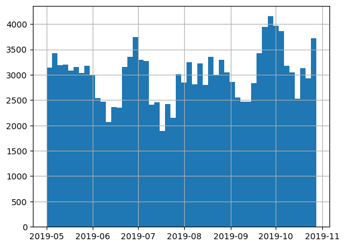

```python
profiles['first_ts'].hist(bins=50);
```

**Распределение пользователей по регионам**

```python
regions = profiles.pivot_table(index='region', values='payer', aggfunc=['count', 'sum'])
regions.columns = ['all_users', 'payers']
regions = regions.sort_values(by='payers', ascending = False)

regions['conversion'] = (regions['payers'] / regions['all_users']).round(4)

regions
```

| region | all_users | payers | conversion |
| --- | --- | --- | --- |
| United States | 100002 | 6902 | 0.0690 |
| UK | 17575 | 700 | 0.0398 |
| France | 17450 | 663 | 0.0380 |
| Germany | 14981 | 616 | 0.0411 |

Как видно из таблицы, наибольшее количество пользователей из США, конверсия в данном регионе также наибольшая. Следовательно, стоит уделить наибольшее внимание именно данной категории.

**Распределение пользователей по используемым устройствам**

```python
devices = profiles.pivot_table(index='device', values='payer', aggfunc=['count', 'sum'])
devices.columns = ['all_users', 'payers']
devices = devices.sort_values(by='payers', ascending = False)

devices['conversion'] = (devices['payers'] / devices['all_users']).round(4)

devices
```

| device | all_users | payers | conversion |
| --- | --- | --- | --- |
| iPhone | 54479 | 3382 | 0.0621 |
| Android | 35032 | 2050 | 0.0585 |
| Mac | 30042 | 1912 | 0.0636 |
| PC | 30455 | 1537 | 0.0505 |

Наибольшее число пользователей, как всего, так и совершивших покупки пользуются iPhone, однако разнича конверсии и общего количества не настолько значительная

**Распределение пользователей по каналам привлечения**

Необходимо сравнить количество привлеченных пользователей по каждому из рекламных источников с затратами на их привлечение.

Распределение количества пользователей по каналам можно польчить из таблицы `profiles`

```python
channels = profiles.pivot_table(index='channel', values='payer', aggfunc=['count', 'sum'])
channels.columns = ['all_users', 'payers']
channels = channels.sort_values(by='payers', ascending = False)

channels['conversion'] = (channels['payers'] / channels['all_users']).round(4)

channels
```

| channel | all_users | payers | conversion |
| --- | --- | --- | --- |
| FaceBoom | 29144 | 3557 | 0.1220 |
| TipTop | 19561 | 1878 | 0.0960 |
| organic | 56439 | 1160 | 0.0206 |
| WahooNetBanner | 8553 | 453 | 0.0530 |
| AdNonSense | 3880 | 440 | 0.1134 |
| RocketSuperAds | 4448 | 352 | 0.0791 |
| LeapBob | 8553 | 262 | 0.0306 |
| OppleCreativeMedia | 8605 | 233 | 0.0271 |
| lambdaMediaAds | 2149 | 225 | 0.1047 |
| YRabbit | 4312 | 165 | 0.0383 |
| MediaTornado | 4364 | 156 | 0.0357 |

Распределение затрат можно получить из таблицы `costs`

```python
cost_pivot = costs.pivot_table(index='channel', values='costs', aggfunc='sum')\
.sort_values(by='costs', ascending = False)

cost_pivot
```

| channel | costs |
| --- | --- |
| TipTop | 54751.30 |
| FaceBoom | 32445.60 |
| WahooNetBanner | 5151.00 |
| AdNonSense | 3911.25 |
| OppleCreativeMedia | 2151.25 |
| RocketSuperAds | 1833.00 |
| LeapBob | 1797.60 |
| lambdaMediaAds | 1557.60 |
| MediaTornado | 954.48 |
| YRabbit | 944.22 |

Далее полученные таблицы объединяются для получения сводных данных по каждому из каналов.

```python
channels = channels.set_index(channels.index).join(cost_pivot.set_index(cost_pivot.index)).fillna(0)\
.sort_values(by='all_users', ascending=False)

channels['price_per_user'] = channels['costs'] / channels['all_users']
channels['price_per_paid_user'] = channels['costs'] / channels['payers']

channels
```

| channel | all_users | payers | conversion | costs | price_per_user | price_per_paid_user |
| --- | --- | --- | --- | --- | --- | --- |
| organic | 56439 | 1160 | 0.0206 | 0.00 | 0.000000 | 0.000000 |
| FaceBoom | 29144 | 3557 | 0.1220 | 32445.60 | 1.113286 | 9.121619 |
| TipTop | 19561 | 1878 | 0.0960 | 54751.30 | 2.799003 | 29.154047 |
| OppleCreativeMedia | 8605 | 233 | 0.0271 | 2151.25 | 0.250000 | 9.232833 |
| WahooNetBanner | 8553 | 453 | 0.0530 | 5151.00 | 0.602245 | 11.370861 |
| LeapBob | 8553 | 262 | 0.0306 | 1797.60 | 0.210172 | 6.861069 |
| RocketSuperAds | 4448 | 352 | 0.0791 | 1833.00 | 0.412095 | 5.207386 |
| MediaTornado | 4364 | 156 | 0.0357 | 954.48 | 0.218717 | 6.118462 |
| YRabbit | 4312 | 165 | 0.0383 | 944.22 | 0.218975 | 5.722545 |
| AdNonSense | 3880 | 440 | 0.1134 | 3911.25 | 1.008054 | 8.889205 |
| lambdaMediaAds | 2149 | 225 | 0.1047 | 1557.60 | 0.724802 | 6.922667 |

Наибольшее количество пользователей *органические*, однако их конверсия в покупателей заметно ниже.

Среди пользователей, привлеченных посредством рекламных кампаний особенно выделяются сети `FaceBoom` и `TipTop`, через которые пришло большинство пользователей.

## Маркетинговые расходы

Следует более детально изучить расходы на различные рекламные кампании, а также визуализировать их посредством графиков и диаграмм.

```python
costs['week'] = costs['dt'].astype('datetime64[W]')
costs['month'] = costs['dt'].astype('datetime64[M]')
```

```python
costs_by_month = costs.pivot_table(index='month', columns='channel', values='costs', aggfunc='sum')
costs_by_week = costs.pivot_table(index='week', columns='channel', values='costs', aggfunc='sum')
costs_by_week_total = costs.pivot_table(index='week', columns='channel', values='costs', aggfunc='sum').cumsum()
```

Для этого построим графики расходов на каждую из платформ привлечения клиентов

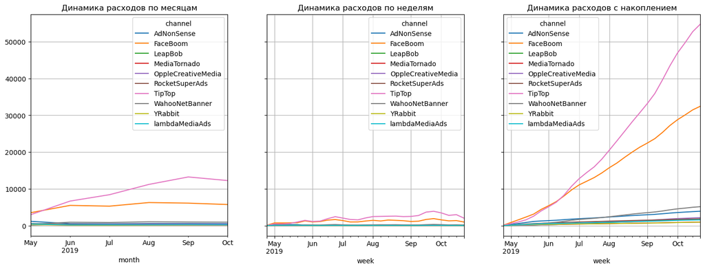

```python
plt.figure(figsize=(18, 6))

# Строим график по месяцам
ax1 = plt.subplot(1, 3, 1)
costs_by_month.plot(grid=True, ax=ax1);
plt.title('Динамика расходов по месяцам');

# Строим график по неделям
ax2 = plt.subplot(1, 3, 2, sharey = ax1)
costs_by_week.plot(grid=True, ax=ax2);
plt.title('Динамика расходов по неделям');

# Строим график по неделям
ax3 = plt.subplot(1, 3, 3, sharey = ax1)
costs_by_week_total.plot(grid=True, ax=ax3);
plt.title('Динамика расходов с накоплением');

plt.show();
```

Из полученных данных можно сделать следующие выводы:

- Расходы на платформе `TipTop` выросли более чем вдвое за последние полгода
- Наибольшие средства на маркетинг затрачены на платформах `FaceBoom` и `TipTop`

Далее с помощью гистограммы визуализируем стоимость привлечения клиентов, описанную выше.

```python
cac = profiles.pivot_table(index='channel', values='acquisition_cost', aggfunc=['count','sum'])
cac.columns = ['total_users', 'total_acquisition_cost']
cac['user_acquisition_cost'] = cac['total_acquisition_cost'] / cac['total_users']

cac = cac.sort_values(by='user_acquisition_cost', ascending=True)
```

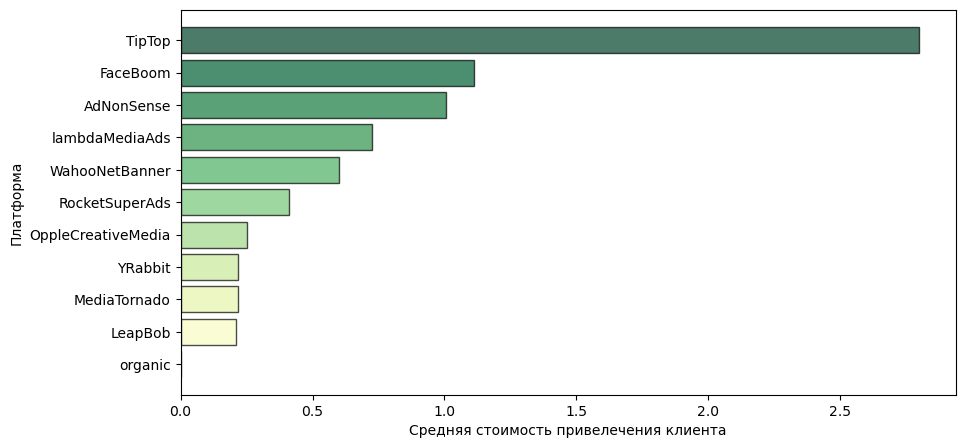

```python
x=cac.index
y=cac['user_acquisition_cost']

plt.figure(figsize=(10,5))

plt.xlabel('Средняя стоимость привелечения клиента')
plt.ylabel('Платформа')

colors = plt.cm.YlGn(np.linspace(0, 1, len(x)))

plt.barh(x, y, color=colors, edgecolor = "black", alpha=0.7)
plt.show()
```

Как видно, стоимость привлечения одного клиента на платформе `Tip Top` значительно выше, чем на других платформах.

## Оценка окупаемости рекламных кампаний

Целевая окупаемость пользователей, привлеченных посредством рекламы составляет 14 дней.  
Используя графики `LTV` и `ROI` оценим, соответствуют ли фактические показатели целевым значениям.

```python
observation_date = datetime(2019, 11, 1).date()  # момент анализа
horizon_days = 14  # горизонт анализа
```

```python
ltv_raw, ltv_grouped, ltv_history, roi_grouped, roi_history = get_ltv(
    profiles, orders, observation_date, horizon_days)
```

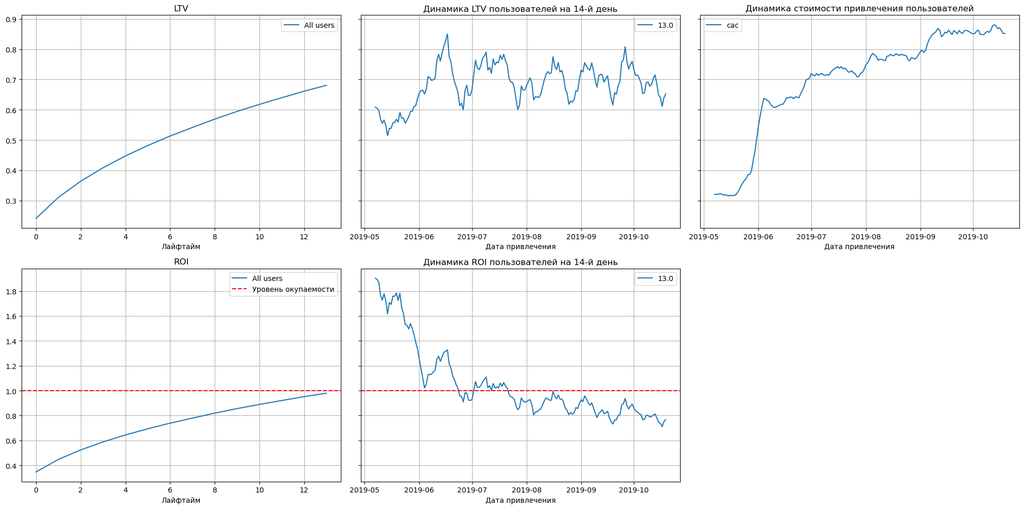

```python
plot_ltv_roi(ltv_grouped, ltv_history, roi_grouped, roi_history, horizon_days)
```

Как видно из графика `ROI`, за 14 дней реклама не окупается. Также стоит отметить, что окупаемость снижается с течением времени и начиная с августа находится ниже порогового значения.

По графику динамики стоимости привлечения пользователей видно, что стоимость рекламы значительно возросла и данный график обратно пропорционален динамике `ROI`. Это может свидетельствовать о том, что снижение окупаемости может быть связано именно с увеличением цены.

Чтобы проверить данную гипотезу, проведем еще ряд исследований.

**1. Исключение из датасета `органических` пользователей для сравнения показателей**

```python
payer_profiles = profiles.query('channel != "organic"')
```

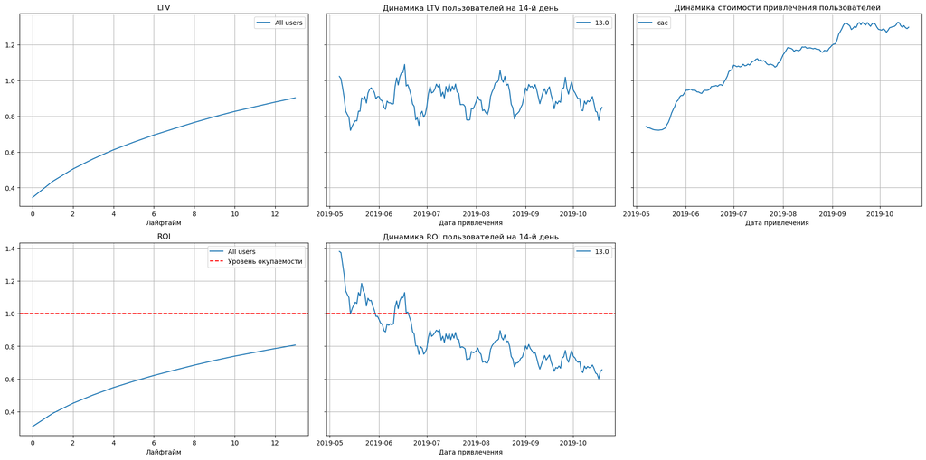

```python
ltv_raw, ltv_grouped, ltv_history, roi_grouped, roi_history = get_ltv(
    payer_profiles, orders, observation_date, horizon_days)

plot_ltv_roi(ltv_grouped, ltv_history, roi_grouped, roi_history, horizon_days)
```

Несмотря на то, что значения изменились, динамика графиков сохранилась. Следовательно, органические пользователи не вносят существенного вклада в окупаемость рекламных кампаний.

**2. Оценка конверсии пользователей**

```python
conversion_raw, conversion_grouped, conversion_history = get_conversion(
    profiles, orders, observation_date, horizon_days, dimensions=[])
```

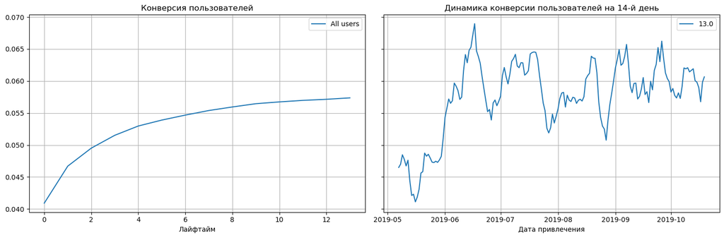

```python
plot_conversion(conversion_grouped, conversion_history, horizon_days)
```

Конверсия достаточно стабильна, более того, в период с середины мая по середину июня наблюдался значительный рост.

Следовательно, конверсия также не является причиной снижения окупаемости.

**3. Оценка удержания пользователей**

```python
retention_raw, retention_grouped, retention_history = get_retention(
    profiles, visits, observation_date, horizon_days, dimensions=[])
```

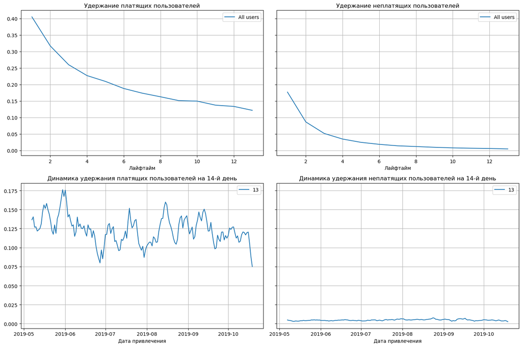

```python
plot_retention(retention_grouped, retention_history, horizon_days)
```

Удержание платящих пользователей ожидаемо выше неплатящих.

В динамике удержания наблюдается слабый нисходящий тренд, однако этого недостаточно для снижения `ROI` более чем в 2 раза.

**4.1. Оценка зависимости основных показателей от используемых устройств**

Поскольку исследования конверсии и удержания не выявили причин падения `ROI`, сделует вернуться к изучению `LTV`, `CAC` и их взаимоотношения, разделив эти величины по различным параметрам.

В данном пункте исследуется зависимость от устройств, с которых пользователи заходят на платформу.

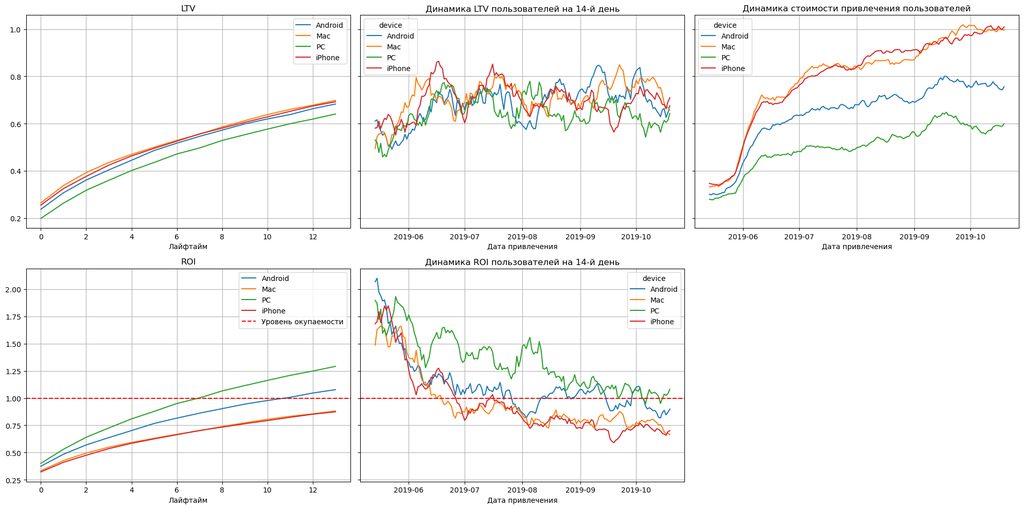

```python
dimensions = ['device']

ltv_raw, ltv_grouped, ltv_history, roi_grouped, roi_history = get_ltv(
    profiles, orders, observation_date, horizon_days, dimensions=dimensions
)

plot_ltv_roi(
    ltv_grouped, ltv_history, roi_grouped, roi_history, horizon_days, window=14
)
```

Окупаемость `iPhone` и `Mac` ниже порогового значения, в то время как стоимость рекламы на этих устройствах наибольшая

Тем не менее, стоит отметить, что поскольку динамика `LTV` и `ROI` одинакова, вероятнее всего снижение окупаемости не зависит от типа используемых устройств.

**4.2. Оценка зависимости основных показателей от региона**

Далее изучается зависимость данных параметров от региона, откуда подключаются пользователи.

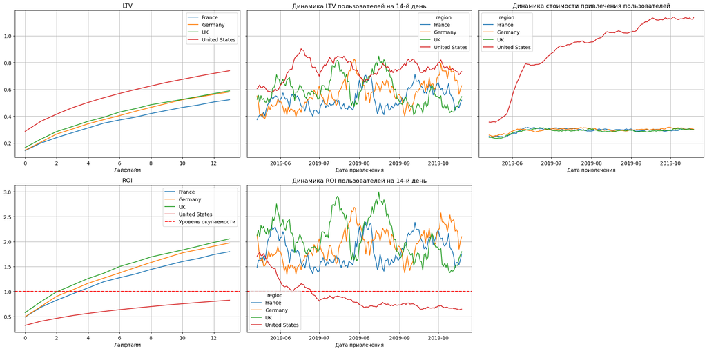

```python
dimensions = ['region']

ltv_raw, ltv_grouped, ltv_history, roi_grouped, roi_history = get_ltv(
    profiles, orders, observation_date, horizon_days, dimensions=dimensions
)

plot_ltv_roi(
    ltv_grouped, ltv_history, roi_grouped, roi_history, horizon_days, window=14
)
```

В результатах данного исследования заметен резкий рост стоимости рекламы в США. За тот же период наблюдается снижение окупаемости и отличие ее динамики. Определенно, эти параметры связаны и общее снижение окупаемости вызвано снижением окупаемости в США, поскольку именно эти пользователи составляют около 80% от всех платящих пользователей.

**4.3. Оценка зависимости основных показателей от канала привлечения**

Заключительным этапом является изучение зависимости параметров от канала привлечения пользователей.

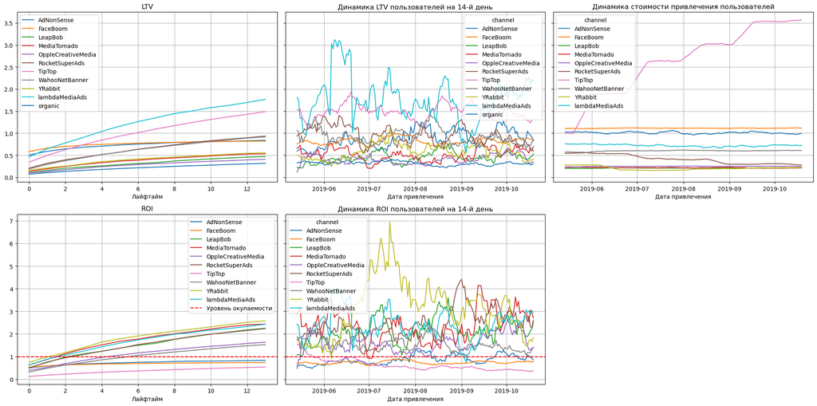

```python
dimensions = ['channel']

ltv_raw, ltv_grouped, ltv_history, roi_grouped, roi_history = get_ltv(
    profiles, orders, observation_date, horizon_days, dimensions=dimensions
)

plot_ltv_roi(
    ltv_grouped, ltv_history, roi_grouped, roi_history, horizon_days, window=14
)
```

Также заметнен значительный рост стоимости размещения рекламы на платформе `TipTop` и снижение `ROI` данного канала.

Вероятно, полученные данные о росте стоимости о падения `ROI` для платформы `TipTop`, региона `США` и устройств `iPhone` и `Mac` связаны между собой, так как пользователи из США могут предпочитать устройства `iPhone` и `Mac`, а также чаще других пользоваться платформой `TipTop`.

## Выводы

В результате исследования было выявлено, что падение окупаемости рекламы связано в первую очередь с ростом стоимости привлечения пользователей.  
Наибольший рост стоимости зафиксирован в регионе `США`, а также для устройств `iPhone` и `Mac`, и платформы `TipTop`.

Тем не менее, для планирования дальнейших действий по повышению эффективности рекламных кампаний следует учесть, что порядка 80% платящих пользователей находятся именно в регионе `США`, поэтому отказ от рекламы в данном регионе может быть крайне рискованным.

В то же время, среди устройств и рекламных платформ имеются альтернативы:  
К примеру, пользователей устройств на базе `Android` больше, чем пользователей `Mac`, а их конверсия незначительно ниже.  
Среди рекламных платформ `FaceBoom` показывает более высокую эффективность, чем `TipTop` как по количеству пользователей, так и по конверсии. Стоимость привлечения пользователей при этом у `FaceBoom` в 2-3 раза ниже, чем у `TipTop`.